# A Brief Tour of the Tidyverse with Simulated Covid Data

Abe Kazemzadeh

11/3/2020

## Tidy Data

In the Tidy Data paper, we saw kind of “domain language” for data preparation. Domain languages like this help us express concepts which are otherwise clumsy and hard to express. However, the terminology in the paper has changed over time as it has been implemented in the Tidyverse libraries, so it is important to understand the underlying concepts behind the terminology.

We will explore the Tidyverse by loading each library separately, namely `readr`, `magrittr` `dplyr`, `tidyr`, and `ggplot2`. In practice, you may simply load these and other Tidyverse libraries with `library(tidyverse)`.

If you haven’t already, you should install the Tidyverse

```r
# note, eval=FALSE means that this is not evaluated in the normal knitting process
# You should run this in the console
install.packages("tidyverse")
```

## Reading Data

In order to use `read_csv`, we first need to load the `readr` library.

```r
library(readr)
```

We need to set where to find the data file (you may omit the `setwd` line if the data file is in the same directory as this RMarkdown file).

```r
setwd("~/Downloads")
sir_tibble <- read_csv("daily_infections.csv")
```

The data is stored in the form of a “tibble”, which is short for “tidy table”. When you type the name of the tibble, it will print a shortened version of the table, like we did with `head()` and a normal, base-R table

```r
sir_tibble
```

| susceptible | infected | recovered | date |
| --- | --- | --- | --- |
| 97 | 3 | 0 | 2020-03-30 |
| 96 | 3 | 1 | 2020-03-31 |
| 95 | 4 | 1 | 2020-04-01 |
| 92 | 7 | 1 | 2020-04-02 |
| 88 | 10 | 2 | 2020-04-03 |
| 78 | 20 | 2 | 2020-04-04 |
| 61 | 36 | 3 | 2020-04-05 |
| 45 | 51 | 4 | 2020-04-06 |
| 34 | 59 | 7 | 2020-04-07 |
| 21 | 68 | 11 | 2020-04-08 |

[output cut: 40 more lines]

If you want to convert back to a base-R table, you can run the following. Note that this chunk has the option `eval=FALSE` so it won’t show all the long output (50 rows)

```r
as.data.frame(sir_tibble)
```

Also, remember earlier in lecture we showed the object oriented class that the tibble and data frames are derived from. The output for the tibble shows that it is an example of multiple inheritance. If you don’t know what that is, it’s not super important for our purposes, but you can google it if you are curious.

```r
class(sir_tibble)
```

```
## [1] "spec_tbl_df" "tbl_df"      "tbl"         "data.frame"
```

```r
class(as.data.frame(sir_tibble))
```

```
## [1] "data.frame"
```

## “This is not a Pipe”

The pipe operator `%>%` is one of the innovations of the Tidyverse. It captures the idea that tidy tools should take tidy data as input and return tidy data as output. Thus everything flowing through such a pipe is tidy. The `magrittr` library is the library that provides the pipe operator (named after the Belgian painter Rene Magritte, who is famous for his painting of a pipe with the caption, “this is not a pipe”).

```r
knitr::include_graphics("MagritteTreacheryOfImages.jpg")
```

[output not shown]

```r
library(magrittr)
```

The idea is that you can “pipe” the date from one command to another. Recall from the paper that a “tidy” tool/function takes a data table/frame as an input and produces another table/frame as an output. Thus, as long as each tool/function is “tidy” we can connect them together using the `magrittr` pipes. This is really just the same as calling functions with paretheses in base-R, but using pipes makes the flow of data clearer and solves the problem of having deeply nested parentheses that are hard to count. For example, in the following command, the `sir_tibble` data frame is piped to the tidy function `summarize`, which returns a data frame with the summary columns (in this example, there is only one row in the data frame returned by `summarize`). Summarize is in the `dplyr` library.

```r
library(dplyr)
sir_tibble %>% summarize(n=n(),
                         start=min(date),
                         end=max(date),
                         population=max(susceptible,
                                        infected,
                                        recovered))
```

| n | start | end | population |
| --- | --- | --- | --- |
| 50 | 2020-03-30 | 2020-07-21 | 100 |

Note that I’ve added new-lines and indentation to keep the code clean. The indentation should be mostly automatic when you use RStudio and hit return after a comma.

The base-R way of calling this would simply give sir_table as an argument in the parentheses of `summarize`. This is still pretty readable, but you can imagine with more nesting, the parentheses will get annoying and hard to read.

```r
summarize(sir_tibble,
          n=n(),
          start=min(date),
          end=max(date),
          population=max(susceptible, infected, recovered))
```

| n | start | end | population |
| --- | --- | --- | --- |
| 50 | 2020-03-30 | 2020-07-21 | 100 |

## Tidying the Data, the Base-R Way

To Tidy the data, first we’ll try the base-R way. We’ve seen this already a few times in the hands-on activities.

```r
# first duplicate the dates 3x
dates_combined <- c(sir_tibble$date,
                    sir_tibble$date,
                    sir_tibble$date)

# then "melt" the 3 people count columns
counts_combined <- c(sir_tibble$susceptible,
                     sir_tibble$infected,
                     sir_tibble$recovered)

# next create a disease state categorical variable
n <- dim(sir_tibble)[1]
disease_state <- c(rep("susceptible", n),
                   rep("infected", n),
                   rep("recovered", n))

sir_tible_base_r_tidy <- tibble(date=dates_combined,
                                disease_state=disease_state,
                                count=counts_combined)
```

Now that the date is tidy, we can use functions like `group_by`, also in the `dplyr` library.

```r
sir_tible_base_r_tidy %>%
  group_by(disease_state)  %>%
  summarize(n=n(), start=min(date), end=max(date))
```

| disease_state | n | start | end |
| --- | --- | --- | --- |
| infected | 50 | 2020-03-30 | 2020-07-21 |
| recovered | 50 | 2020-03-30 | 2020-07-21 |
| susceptible | 50 | 2020-03-30 | 2020-07-21 |

## Tidying with Tidyr

Keeping with the approach in class, we’ve started with Base-R and moved on to Tidy R. The `tidyr` library has tools to do this, namely `pivot_longer` (older versions of the library called it `melt` but as far as I can tell they have been moving from “cute” names to more “businessy” names). `pivot_wider` would undo this transformation.

```r
library(tidyr)
sir_tibble %>% pivot_longer(cols=c("susceptible", "infected","recovered"))
```

| date | name | value |
| --- | --- | --- |
| 2020-03-30 | susceptible | 97 |
| 2020-03-30 | infected | 3 |
| 2020-03-30 | recovered | 0 |
| 2020-03-31 | susceptible | 96 |
| 2020-03-31 | infected | 3 |
| 2020-03-31 | recovered | 1 |
| 2020-04-01 | susceptible | 95 |
| 2020-04-01 | infected | 4 |
| 2020-04-01 | recovered | 1 |
| 2020-04-02 | susceptible | 92 |

[output cut: 140 more lines]

Just specifying the columns results in new columns labelled “name” and “value”. To give custom names:

```r
sir_tibble %>%
  pivot_longer(cols=c("susceptible", "infected","recovered"),
               names_to = "disease_state", values_to = "count")
```

| date | disease_state | count |
| --- | --- | --- |
| 2020-03-30 | susceptible | 97 |
| 2020-03-30 | infected | 3 |
| 2020-03-30 | recovered | 0 |
| 2020-03-31 | susceptible | 96 |
| 2020-03-31 | infected | 3 |
| 2020-03-31 | recovered | 1 |
| 2020-04-01 | susceptible | 95 |
| 2020-04-01 | infected | 4 |
| 2020-04-01 | recovered | 1 |
| 2020-04-02 | susceptible | 92 |

[output cut: 140 more lines]

## Plotting with Ggplot

The first library we saw in the Tidyverse was `ggplot2`. We’ve seen a couple of examles where it helps to have data in a tidy format to make it easier to plot. Just to make sure we remember, let’s try to plot the messy table before it was “melted”:

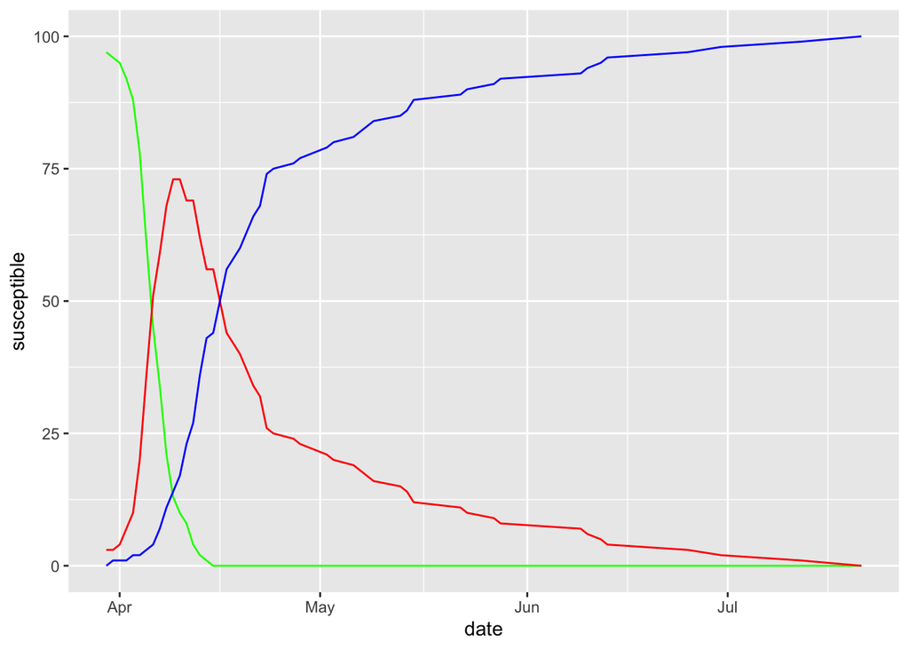

```r
library(ggplot2)
ggplot(sir_tibble, aes(x=date)) +
  geom_line(aes(y=susceptible), color="green") +
  geom_line(aes(y=infected), color="red") +
  geom_line(aes(y=recovered), color="blue")
```

Remember that the theory behind ggplot involves mapping data variables to visual variables using the `aes` aesthetic mapping. Note that the color setting is outside of the `aes` aesthetic mapping and the `x` visual variable is set in the `ggplot` command so that it will be a default across the following `geom_line` commands.

The benefit of the tidy approach is that we will be able to use color as a visual variable for the `disease_state` data variable, so the ggplot command will only require one `geom_line` command. I’m going to use the `magritter` pipes to show how commands may be chained together.

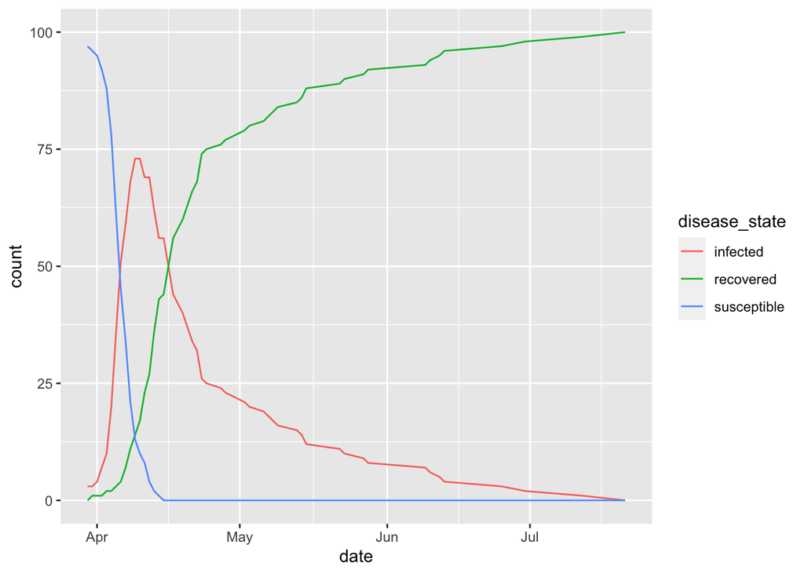

```r
sir_tibble %>%
  pivot_longer(cols=c("susceptible", "infected","recovered"),
               names_to = "disease_state", values_to = "count") %>%
  ggplot(aes(x=date)) + geom_line(aes(y=count,
                                      color=disease_state))
```

Notice now the colors are assigned automatically and there’s a legend included automatically as well. To get exactly the same colors we had before we can do the following:

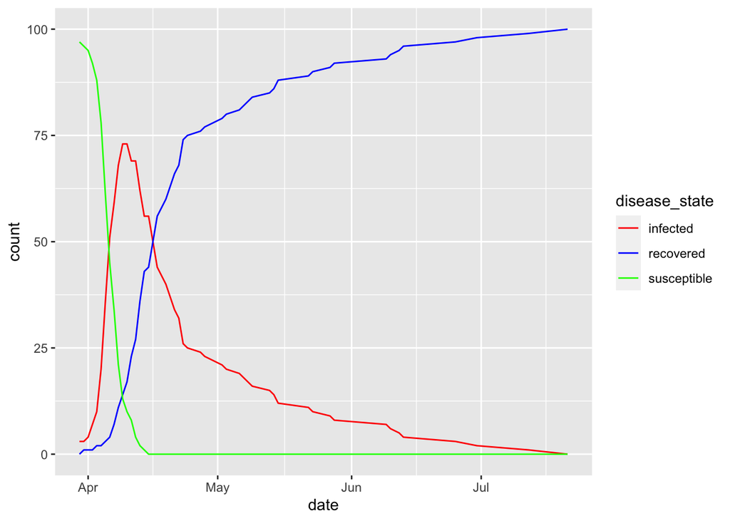

```r
sir_tibble %>%
  pivot_longer(cols=c("susceptible", "infected","recovered"),
               names_to = "disease_state", values_to = "count") %>%
  ggplot(aes(x=date)) + geom_line(aes(y=count,
                                      color=disease_state)) +
scale_color_manual(values=c("red", "blue", "green"))
```

## Back to Where We Started

We can use the `tidyr` function `pivot_wider` to convert to our messy table with counts in three columns:

```r
sir_tibble %>%
  pivot_longer(cols=c("susceptible", "infected","recovered"),
               names_to = "disease_state",
               values_to = "count") %>%
  pivot_wider(names_from="disease_state",
              values_from="count")
```

| date | susceptible | infected | recovered |
| --- | --- | --- | --- |
| 2020-03-30 | 97 | 3 | 0 |
| 2020-03-31 | 96 | 3 | 1 |
| 2020-04-01 | 95 | 4 | 1 |
| 2020-04-02 | 92 | 7 | 1 |
| 2020-04-03 | 88 | 10 | 2 |
| 2020-04-04 | 78 | 20 | 2 |
| 2020-04-05 | 61 | 36 | 3 |
| 2020-04-06 | 45 | 51 | 4 |
| 2020-04-07 | 34 | 59 | 7 |
| 2020-04-08 | 21 | 68 | 11 |

[output cut: 40 more lines]